# **Homework 7**

Kevin Ha

September 21, 2021

### **Problem 12.31**

##### Problem 12.31a

```
##            Sample Size Sample Mean Sample Standard Deviation
## Control          35.00       -1.01                     11.50
## Group            34.00      -10.79                     11.14
## Individual       35.00       -3.71                      9.08
```

##### Problem 12.31b

**Yes, because the largest standard deviation is less than twice the smallest. $(11.50 < 2(9.08))$**

##### Problem 12.31c

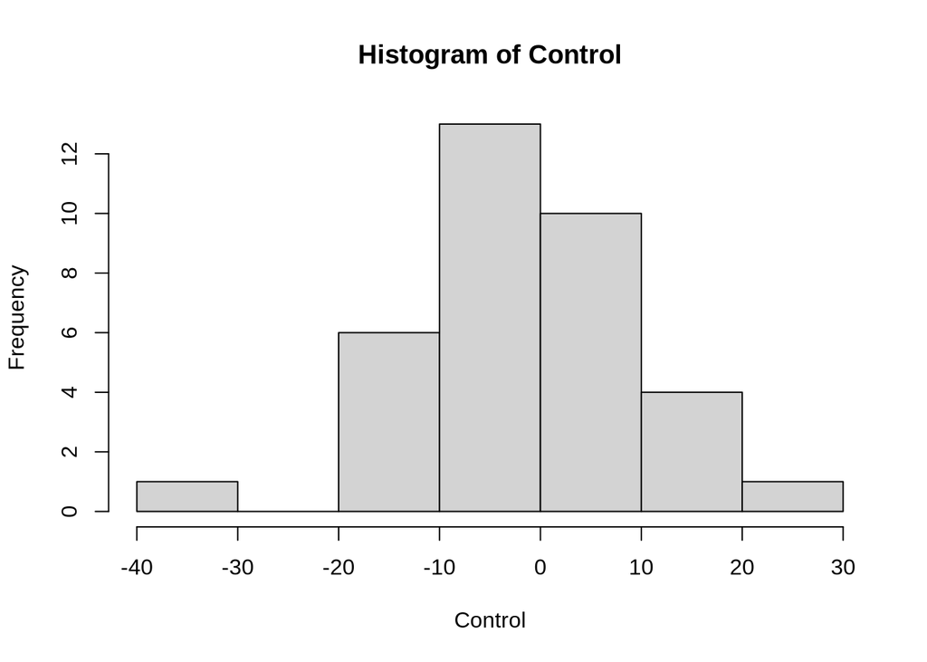

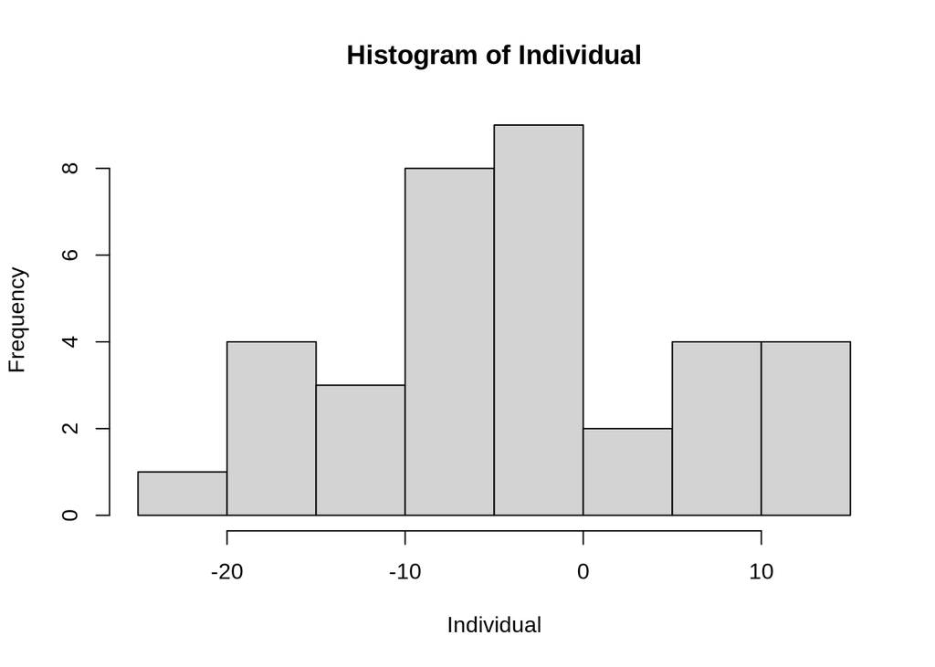

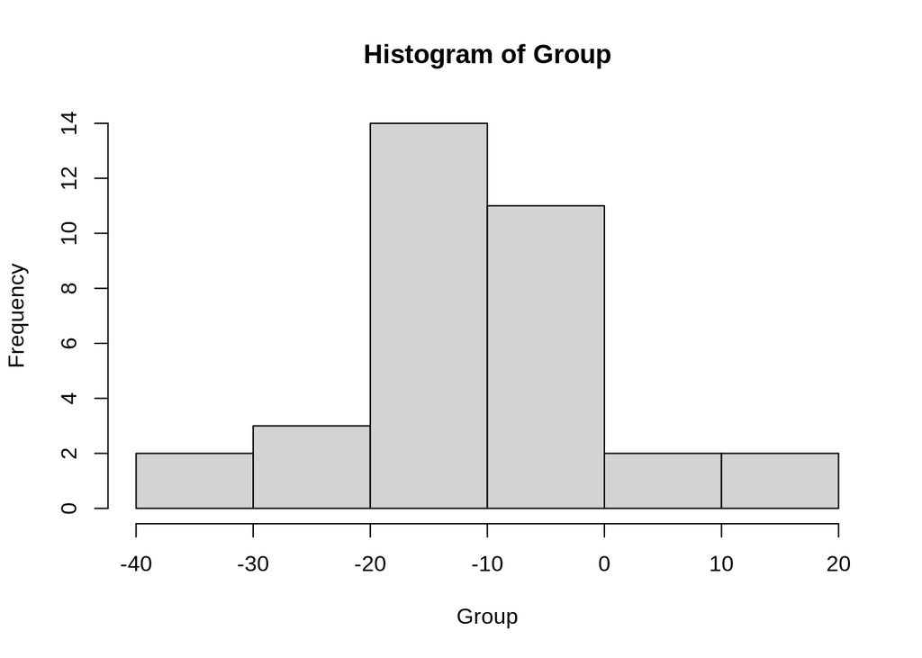

**We can be confident that the samples means are approximately normal as most of the groups appear symmetric from the histogram distribution and have a sample size > 15.**

### **Problem 12.32**

##### Problem 12.32a

One way ANOVA:

$\bar{X} = \frac{(n_1\bar{X_1} + n_2\bar{X_2} + n_3\bar{X_3})}{(n_1 + n_2 + n_3)} = \frac{(35*-1.01 + 34*-10.79 + 35*-3.71)}{(35+34+35)} = -5.12$

$SSB = \sum^3_{i=1}n_i(\bar{X}_i - \bar{X})^2 = 35(-1.01 + 5.12)^2 + 34(-10.79 + 5.12)^2 + 35(-3.71 + 5.12)^2 = 1753.87`$

$SSE = \sum^3_{i=1}(n_i - 1)S^2_i = (35-1)(11.50)^2 + (34-1)(11.14)^2 + (35-1)(9.08)^2 = 11394.96$

$f = \frac{MSB}{MSE} = \frac{SSB/(k-1)}{SSE/(n-k)}= \frac{1753.87/(3-1)}{11394.96/(104-3)} = 7.77$

```r
pf(7.77, 2, 104-3, lower.tail = FALSE)
```

```
## [1] 0.0007265093
```

**Summary: Because of the p-value is less than 0.05, the null hypothesis can be rejected and thus the group population means are not all equal.**

##### Problem 12.32b

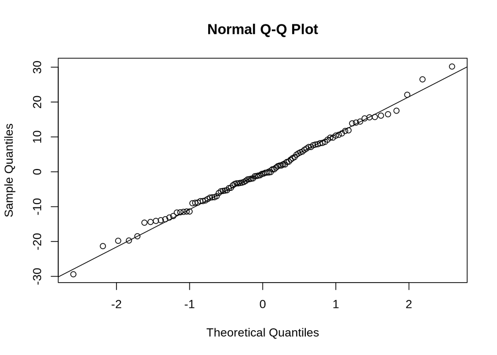

**Again, we can feel confident that the sample means are approximately normal as a vast majority of the residuals follow the straight diagonal line of the QQ-plot, indicating strong evidence of normality.**

##### Problem 12.32c

Testing statistic for comparing two means:

$T_{i,j} = \frac{\bar{X_i}- \bar{X_j}}{\sqrt{S^2_p(\frac{1}{n_i} + \frac{1}{n_j})}}$

Pooled sample variance:

$S^2_p = MSE = \frac{SSE}{n-k} = \frac{11394.96}{(104−3)} = 112.82$

$T_{Individual,Group} = \frac{-3.71 + 10.79}{\sqrt{112.82(\frac{1}{35} + \frac{1}{34})}} = 2.77$

$T_{Control,Individual} = \frac{-1.01 + 3.71}{\sqrt{112.82(\frac{1}{35} + \frac{1}{35})}} = 1.06$

$T_{Control,Group} = \frac{-1.01 + 10.79}{\sqrt{112.82(\frac{1}{35} + \frac{1}{35})}} = 3.82$

LSD for $T_{Individual,Group}$

```r
2*(1-pt(2.77, 104-3))
```

```
## [1] 0.006672348
```

LSD for $T_{Control,Individual}$

```r
2*(1-pt(1.06, 104-3))
```

```
## [1] 0.2916729
```

LSD for $T_{Control,Group}$

```r
2*(1-pt(3.82, 104-3))
```

```
## [1] 0.0002306425
```

##### Problem 12.32d

Based on the results of the (a), (b), (c) the null hypothesis ($H_0: \mu_1 = \mu_2 = \mu_3$) fails to be rejected when comparing the Control and Individual groups as the calculated LSD values is greater than 0.05, while the $H_0$ is rejected when comparing Control / Group & Individual & Group as both groups have a LSD value < 0.05.

### Problem 12.33

##### Problem 12.33a

```
##            Sample Size Sample Mean Sample Standard Deviation
## Control     35.0000000  -0.4584416                 5.2276025
## Group       34.0000000  -4.9024064                 5.0632505
## Individual  35.0000000  -1.6857143                 4.1265290
```

##### Problem 12.33b

One way ANOVA:

$\bar{X} = \frac{(n_1\bar{X_1} + n_2\bar{X_2} + n_3\bar{X_3})}{(n_1 + n_2 + n_3)} = \frac{(35*-0.46 + 34*-4.90 + 35*-1.69)}{(35+34+35)} = -2.33$

$SSB = \sum^3_{i=1}n_i(\bar{X}_i - \bar{X})^2 = 35(-0.46 + 2.33)^2 + 34(-4.90 + 2.33)^2 + 35(-1.69 + 2.33)^2 = 361.29`$

$SSE = \sum^3_{i=1}(n_i - 1)S^2_i = (35-1)(5.23)^2 + (34-1)(5.06)^2 + (35-1)(4.13)^2 = 2354.85`$

$f = \frac{MSB}{MSE} = \frac{SSB/(k-1)}{SSE/(n-k)}= \frac{361.29/(3-1)}{2354.85/(104-3)} = 7.75$

```r
pf(7.75, 2, 104-3, lower.tail = FALSE)
```

```
## [1] 0.0007392139
```

**Summary: Because of the p-value is less than 0.05, the null hypothesis can be rejected and thus the group population means are not all equal.**

### Problem 12.41

##### Problem 12.41a

Asking for average of blue and green eye color: $(\mu_1 + \mu_4)/2$

$\psi_1 = \mu_2 - (\mu_1 + \mu_4) / 2$

##### Problem 12.41b

Looking up are the linear combinations of each eye color: $\mu_1 + \mu_2 + \mu_4$

Taking the average of the combination above and contrasting it with the looking down ($\mu_3$):

$\psi_2 = \frac{(\mu_1 + \mu_2 + \mu_4)}{3} - \mu_3$

### Problem 12.42

##### Problem 12.42a

Eye Color Contrast:

$H_0: \psi_1 = 0$

$H_a: \psi_1 \neq 0$

Looking Contrast:

$H_0: \psi_2 = 0$

$H_a: \psi_2 \neq 0$

##### Problem 12.42b

```
##       Sample Size Sample Mean Sample Standard Deviation
## Blue        67.00        3.19                      1.75
## Brown       37.00        3.72                      1.72
## Down        41.00        3.11                      1.53
## Green       77.00        3.86                      1.67
```

$c_1 = \mu_2 - (\mu_1 + \mu_4) / 2 = 3.72 - (3.19+3.86) / 2 = 0.195$

$c_2 = \frac{(\mu_1 + \mu_2 + \mu_4)}{3} - \mu_3 = \frac{(3.19 + 3.72 + 3.86)}{3} - 3.11 = 0.48$

##### Problem 12.42c

Pooled sample variance:

$S^2_p = \sqrt{MSE} = \sqrt{\frac{SSE}{n-k}} = \sqrt{\frac{(67-1)(1.75)^2+(37-1)(1.72)^2+(41-1)(1.53)^2 + (77-1)(1.67)^2}{(221-4)}} =2.830506$

Formula for standard error of c:

$SE_c = \sqrt{S_p^2\sum^3_{i=1}\frac{a_i^2}{\bar{x}_i}}$

$SE_{c_1} = \sqrt{2.83 *(\frac{(-1^2)}{37} + \frac{(1/2)^2}{67} + \frac{(-1/2)^2}{77}) } = 0.30$

$SE_{c_2} = \sqrt{2.83 *(\frac{(-1^2)}{41} + \frac{(1/3)^2}{67} + \frac{(-1/3)^2}{77} + \frac{(-1/3)^2}{37})} = 0.29$

##### Problem 12.42d

$t = \frac{c_{\psi}}{SE_c}$

For contrast (eye color): $t_1 = \frac{0.195}{0.30} = 0.64$

```r
2*pt(0.64, 220 - 4, lower.tail = FALSE)
```

```
## [1] 0.5228509
```

For contrast (looking): $t_1 = \frac{0.48}{0.29} = 1.66$

```r
2*pt(1.66, 220 - 4, lower.tail = FALSE)
```

```
## [1] 0.09836549
```

Conclusion:

For contrast (eye-color) we fail to reject the null hypothesis since the calculated p-value > 0.05, for the contrast (looking) we also fail to reject since the p-value is > 0.05.

##### Problem 12.42e

$df = 222 - 1 = 221$

```r
abs(qt(0.05 / 2, 221))
```

```
## [1] 1.970756
```

95% confidence interval for contrast (eye color):

$\psi_1: 0.195 \pm (1.97*0.30) = (-0.40, 0.79)$

95% confidence interval for contrast (looking):

$\psi_2: 0.48 \pm (1.97*0.29) = (-0.09, 1.05)$